# Employee Attrition Analaysis

## EDA for Employee monthly Income Analysis vs Features

```r
employeemonthly<-employee


#
# ggplot(data=employeemonthly,aes(x=MonthlyIncome,y=Age))+geom_point(color="blue")+ggtitle("Employee Monthly Income vs Age")
#
#
# ggplot(data=employeemonthly,aes(x=MonthlyIncome,y=TotalWorkingYears))+geom_point(color="red")+ggtitle("Employee Monthly Income vs Years Of Experience")
#
#
# ggplot(data=employeemonthly,aes(x=MonthlyIncome,y=YearsAtCompany))+geom_point(color="green")+ggtitle("Employee Monthly Income vs Years At Company")
#
#
#
# ggplot(data=employeemonthly,aes(x=MonthlyIncome,y=JobLevel))+geom_point(color="plum")+ggtitle("Employee Monthly Income vs Job Level")
#
#
# ggplot(employeemonthly,aes(y=employeemonthly,x=Age,color=TotalWorkingYears))+geom_point()
#
#
# plot_grid(s1,s2,s3,s4,ncol=2,nrow=2)
```

```r
employeemonthly<-employee_updated



set.seed(8)
splitPerc = .7

trainIndices = sample(1:dim(employeemonthly)[1], round(splitPerc * dim(employeemonthly)[1]))
train.Income = employeemonthly[trainIndices,]
test.Income = employeemonthly[-trainIndices,]



employeeSalaryPred<-lm(MonthlyIncome ~ Age+TotalWorkingYears+YearsAtCompany+JobLevel,data=train.Income)


PredictSal<-predict(employeeSalaryPred,test.Income)

table(RMSE(test.Income$MonthlyIncome,PredictSal))
```

```
##
## 1449.34376486662
##                1
```

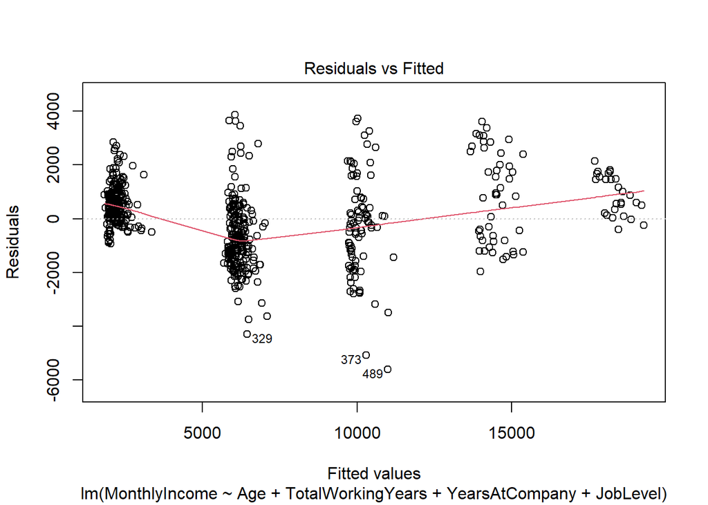

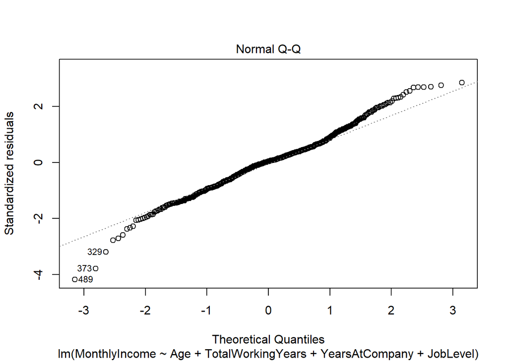

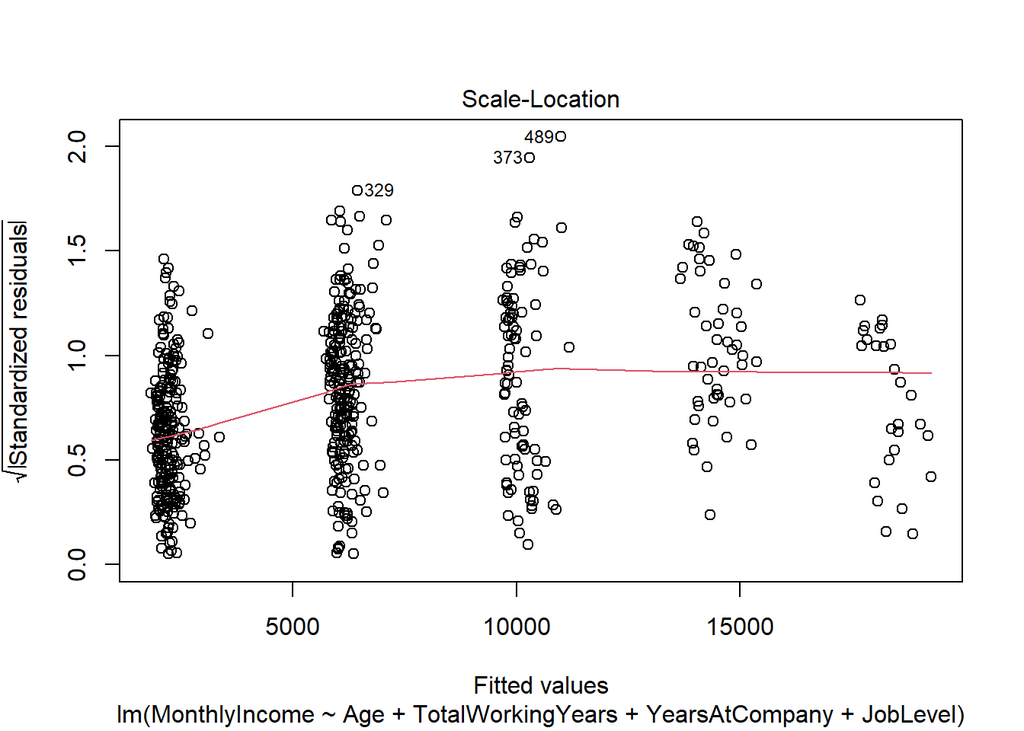

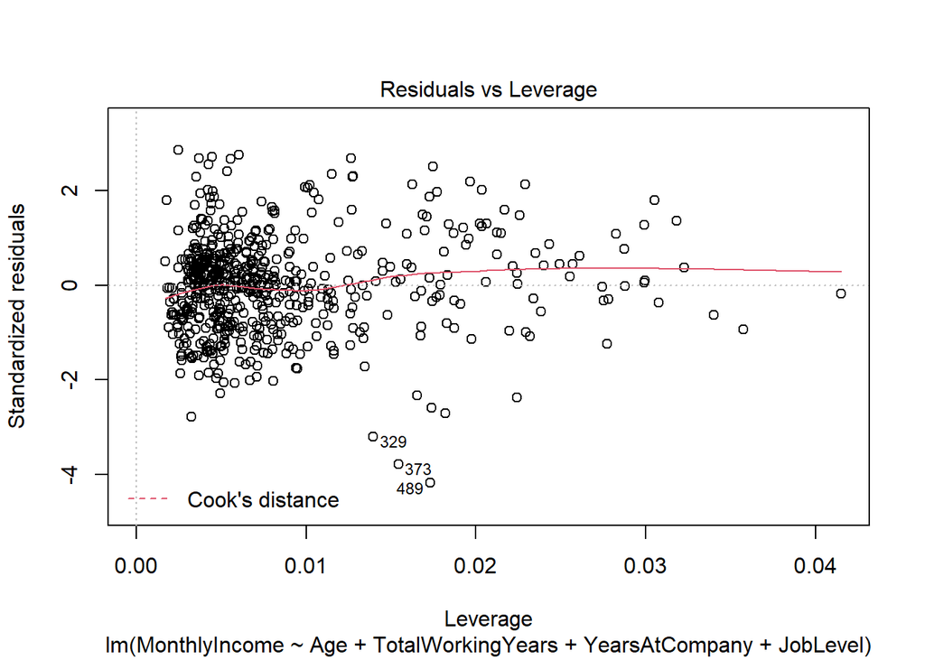

```r
plot(employeeSalaryPred)
```

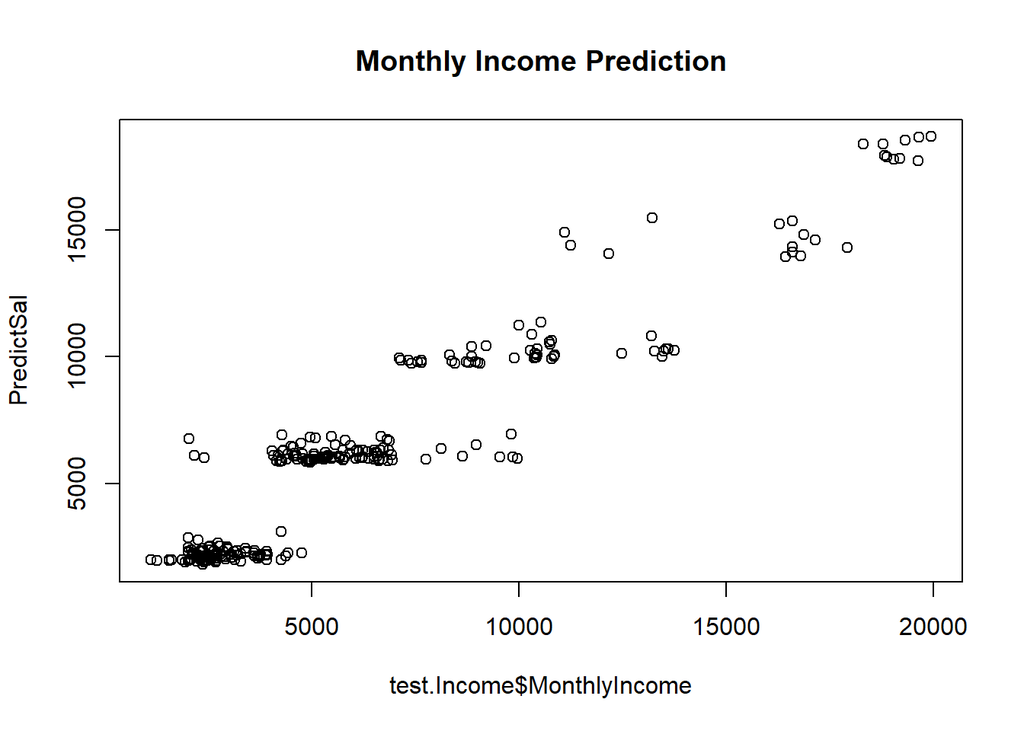

```r
plot(test.Income$MonthlyIncome,PredictSal,type="p",main="Monthly Income Prediction")
```

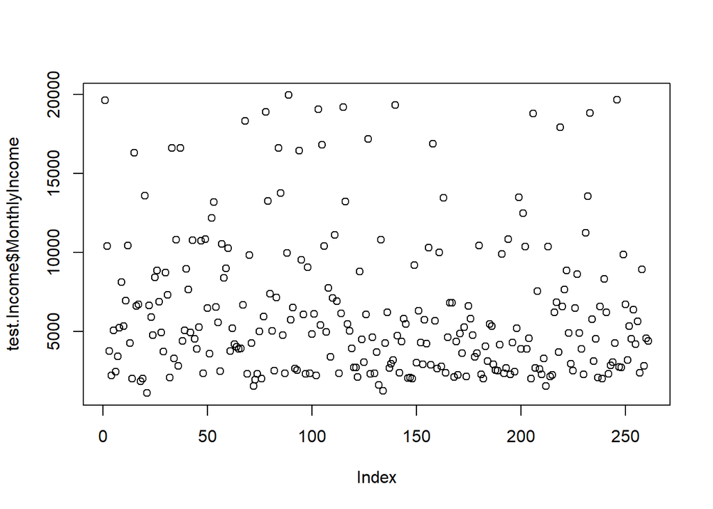

```r
plot(test.Income$MonthlyIncome)
```

## Write attrition predicted values for ‘CaseStudy2CompSet No Attrition.csv’ to csv File

```r
# Read in 'No Attrition' file


employeeRF1<-employee_updated
employeeNoAttrition
```

[output not shown]

[output cut: 2393 more lines]

```r
employeeRF1$Attrition<-as.factor(employeeRF1$Attrition)

rfPredictOriginal=randomForest(Attrition ~ .,data=employeeRF1,strata=employee$Attrition,sampsize=c(60,60))

pred<-predict(rfPredictOriginal,employeeNoAttrition)

Attrition_Pred<-as.data.frame(pred)


ID<-as.data.frame(employeeNoAttrition$ID)

Data_Updated<-cbind(Attrition_Pred,ID)


Attrition_Pred_updated<- merge(x = employeeNoAttrition, y = Data_Updated,
                          by.x = "ID", by.y = "employeeNoAttrition$ID", all = TRUE)


Attrition_Pred_updated$pred
```

```
##   [1] No  No  Yes No  No  No  No  No  No  Yes Yes Yes No  No  Yes No  No  No
##  [19] No  No  Yes No  No  Yes No  No  No  Yes No  Yes No  No  No  No  Yes No
##  [37] No  No  No  No  No  Yes No  No  Yes No  No  No  No  No  No  No  No  No
##  [55] No  No  Yes No  No  Yes No  No  Yes Yes No  Yes No  No  Yes Yes No  No
##  [73] No  No  No  Yes No  No  No  No  No  No  No  No  No  No  No  Yes No  Yes
##  [91] No  No  No  No  No  No  No  No  No  Yes No  No  No  No  Yes No  No  No
## [109] Yes No  Yes No  No  No  Yes No  Yes No  Yes No  No  No  No  No  No  No
## [127] Yes No  No  No  No  No  No  Yes No  No  No  Yes No  Yes No  No  No  No
## [145] No  No  No  Yes No  No  No  No  No  No  Yes Yes No  Yes Yes No  Yes No
## [163] No  No  No  Yes No  Yes No  No  Yes No  No  Yes No  No  No  Yes No  No
## [181] Yes No  No  No  No  No  No  Yes No  No  No  No  No  No  Yes No  No  No
## [199] No  No  No  No  No  No  No  Yes No  No  No  No  No  No  No  No  No  Yes
## [217] Yes No  No  No  No  No  No  No  No  No  No  No  No  No  Yes Yes No  No
## [235] Yes No  Yes No  No  No  No  No  No  Yes No  No  Yes Yes No  Yes Yes No
## [253] No  Yes No  No  No  No  Yes No  No  No  No  No  No  No  No  No  Yes No
## [271] No  Yes No  Yes Yes No  No  No  Yes Yes Yes No  No  No  Yes Yes No  Yes
## [289] Yes Yes No  No  Yes No  Yes No  No  Yes No  No
## Levels: No Yes
```

```r
colnames(Attrition_Pred_updated)[36] <- "Attrition"

# Write to file
write.csv(Attrition_Pred_updated, "case_Study_Updated_Attrition_output", row.names = FALSE, quote=FALSE)
```

## Write attrition predicted values for ‘CaseStudy2CompSet No Attrition.csv’ to csv File

Here we have used the Random Forrest model to predict the attrition of the employeess

```r
# Read in 'No Attrition' file


employeeRF1<-employee_updated
employeeNoAttrition
```

[output not shown]

[output cut: 2393 more lines]

```r
employeeRF1$Attrition<-as.factor(employeeRF1$Attrition)

rfPredictOriginal=randomForest(Attrition ~ .,data=employeeRF1,strata=employee$Attrition,sampsize=c(60,60))

pred<-predict(rfPredictOriginal,employeeNoAttrition)

Attrition_Pred<-as.data.frame(pred)
cbind(Attrition_Pred,ID)
```

```
##     pred employeeNoAttrition$ID
## 1     No                   1171
## 2     No                   1172
## 3    Yes                   1173
## 4     No                   1174
## 5     No                   1175
## 6     No                   1176
## 7     No                   1177
## 8     No                   1178
## 9     No                   1179
## 10   Yes                   1180
## 11   Yes                   1181
## 12   Yes                   1182
## 13    No                   1183
## 14    No                   1184
```

[output cut: 286 more lines]

```r
ID<-as.data.frame(employeeNoAttrition$ID)

Data_Updated<-mutate(Attrition_Pred,ID)

Attrition_Pred_updated<- merge(x = employeeNoAttrition, y = Data_Updated,
                          by.x = "ID", by.y = "employeeNoAttrition$ID", all = TRUE)


Attrition_Pred_updated$pred
```

```
##   [1] No  No  Yes No  No  No  No  No  No  Yes Yes Yes No  No  Yes No  No  No
##  [19] No  No  Yes No  No  Yes No  No  No  Yes No  Yes Yes No  No  No  Yes No
##  [37] No  No  No  No  No  Yes No  No  Yes No  No  No  No  No  No  Yes No  No
##  [55] No  No  Yes No  No  Yes No  No  Yes No  No  Yes No  No  Yes Yes No  No
##  [73] No  Yes No  Yes No  No  No  No  No  No  No  No  No  No  No  No  No  Yes
##  [91] No  No  No  No  No  No  No  No  No  Yes No  No  No  No  Yes No  No  No
## [109] Yes No  Yes No  No  No  No  No  Yes No  Yes No  No  No  No  No  No  No
## [127] Yes No  No  No  No  No  No  Yes No  No  No  No  No  Yes No  No  No  No
## [145] No  No  No  Yes No  No  Yes No  No  No  Yes Yes No  Yes Yes No  Yes No
## [163] No  No  No  Yes No  Yes No  No  Yes No  No  Yes No  No  No  Yes No  No
## [181] Yes No  No  No  No  No  No  Yes No  No  No  No  No  No  No  No  No  No
## [199] No  No  No  No  No  Yes No  Yes No  No  No  No  No  No  No  No  No  Yes
## [217] Yes No  No  No  No  Yes No  No  No  No  No  No  No  No  Yes Yes No  No
## [235] Yes No  Yes No  No  No  No  No  No  Yes No  No  Yes Yes No  Yes Yes No
## [253] No  Yes No  No  No  No  Yes No  No  No  No  No  No  No  No  No  Yes No
## [271] No  Yes No  Yes Yes No  No  No  Yes Yes Yes No  No  No  Yes Yes No  Yes
## [289] Yes Yes No  No  Yes No  Yes No  No  Yes No  No
## Levels: No Yes
```

```r
colnames(Attrition_Pred_updated)[36] <- "Attrition"

# Write to file
write.csv(Attrition_Pred_updated, "Case2PredictionsPearly_PaulAttrition.csv", row.names = FALSE, quote=FALSE)
```

## Write predicted salary values to a csv.

Here we have used Multiple Linear regression to predict the salary of the employee

```r
# Read in 'No Attrition' file


employeelinear<-employee_updated
employeeNoSalary
```

[output not shown]

[output cut: 2393 more lines]

```r
employeelinear$Attrition<-as.factor(employeelinear$Attrition)

employeeSalaryPred1<-lm(MonthlyIncome ~ Age+TotalWorkingYears+YearsAtCompany+JobLevel,data=employeelinear)


PredictSalary<-predict(employeeSalaryPred1,employeeNoSalary)

SalaryPred<-as.data.frame(PredictSalary)

ID_updated<-as.data.frame(employeeNoSalary$ID)

Salary_pred_updated<-cbind(SalaryPred,ID_updated)



Salary_Pred_updated<- merge(x = Salary_pred_updated, y = employeeNoSalary,
                          by.x = "employeeNoSalary$ID", by.y = "ID", all = TRUE)



colnames(Salary_Pred_updated)[2] <- "Monthly_Income"

# Write to file
write.csv(Salary_Pred_updated,"Case2PredictionsPearlyPaulSalary.csv",row.names = FALSE, quote=FALSE)
```

## Conclusion

### Age

Attrition Rate is higest among people who belong to the age group of 30 - 39 years By this we can conclude that employees who have maximum attrition rate are young

### Total Working Years

Employees who have less total working experience between 1-9 years have higher attrition rate HR needs to overlook why young employees have higher attrition rate.

#### Employees’ benefits

Salary plays a major influencing factor to attrition Salary scale varies with the job level

### Stock Option Levels

Employees who dont receive stocks have the higer attrition rate . Providing stocks from the company employees are forced to stay .So providing Stock level options to junior employees would help.

### Job Roles

We were able to observe that half of the employees as Lab Technicians were quiting. Possible due to the over time.

### Overtime & Department & JobLevel & JobRole & BusinessTravel

People who work overtime have the highest Attrition rate and belong to the Research and Sales Department. These employees travel rarely and work low level jobs

### Years at the Company

Employees with higher attrition rate work in the company for around 1-9 years

### Years in Current Role

Most of the employees who leave the company has very less experience in the current role

#### Environment Satisfaction

Employees with low environment satisfication have higher attrition rate.

## RECOMMENDATIONS FROM DDS ANALYTICS :

1. Career counseling and coaching should be provided for new employees
2. Junior Employees should be getting Stock Options as part of their salary package.
3. Employees should not be overloaded by extra work that they are forced to do Overtime
4. Company Promotion criteria should be reviewed regularly at least on a yearly basis.
5. Working environment should be improved . Employees should be able to work were they feel comfortable whether it is the office or at home. 6)We would recommend HR to analyze the Employees in the Research/Sales Department to check if there are any environment issues or work issues that is causing employees to leave the company.